# Modeling COVID-19 Data

## Importing Needed Packages and Reading in Data

```python
#Import Necessary Packages
import pandas as pd
import seaborn as sns
import matplotlib.pyplot as plt
import numpy as np
from sklearn.model_selection import train_test_split
from sklearn.neighbors import KNeighborsClassifier
from sklearn.preprocessing import LabelEncoder
from sklearn.ensemble import RandomForestClassifier
from sklearn.metrics import roc_curve, auc
from sklearn.metrics import classification_report, confusion_matrix, accuracy_score, precision_score, recall_score, roc_auc_score
from sklearn.preprocessing import label_binarize
from sklearn.multiclass import OneVsRestClassifier
import copy
```

```python
#Read in the Covid data
covid = pd.read_csv("C:/Users/roami/OneDrive/Desktop/Fall 2023/Principles and Techniques/Final Exam/Covid Data.csv")
covid
```

|  | USMER | MEDICAL_UNIT | SEX | PATIENT_TYPE | DATE_DIED | INTUBED | PNEUMONIA | AGE | PREGNANT | DIABETES | ... | ASTHMA | INMSUPR | HIPERTENSION | OTHER_DISEASE | CARDIOVASCULAR | OBESITY | RENAL_CHRONIC | TOBACCO | CLASIFFICATION_FINAL | ICU |
| --- | --- | --- | --- | --- | --- | --- | --- | --- | --- | --- | --- | --- | --- | --- | --- | --- | --- | --- | --- | --- | --- |
| 0 | 2 | 1 | 1 | 1 | 03/05/2020 | 97 | 1 | 65 | 2 | 2 | ... | 2 | 2 | 1 | 2 | 2 | 2 | 2 | 2 | 3 | 97 |
| 1 | 2 | 1 | 2 | 1 | 03/06/2020 | 97 | 1 | 72 | 97 | 2 | ... | 2 | 2 | 1 | 2 | 2 | 1 | 1 | 2 | 5 | 97 |
| 2 | 2 | 1 | 2 | 2 | 09/06/2020 | 1 | 2 | 55 | 97 | 1 | ... | 2 | 2 | 2 | 2 | 2 | 2 | 2 | 2 | 3 | 2 |
| 3 | 2 | 1 | 1 | 1 | 12/06/2020 | 97 | 2 | 53 | 2 | 2 | ... | 2 | 2 | 2 | 2 | 2 | 2 | 2 | 2 | 7 | 97 |
| 4 | 2 | 1 | 2 | 1 | 21/06/2020 | 97 | 2 | 68 | 97 | 1 | ... | 2 | 2 | 1 | 2 | 2 | 2 | 2 | 2 | 3 | 97 |
| ... | ... | ... | ... | ... | ... | ... | ... | ... | ... | ... | ... | ... | ... | ... | ... | ... | ... | ... | ... | ... | ... |
| 1048570 | 2 | 13 | 2 | 1 | 9999-99-99 | 97 | 2 | 40 | 97 | 2 | ... | 2 | 2 | 2 | 2 | 2 | 2 | 2 | 2 | 7 | 97 |
| 1048571 | 1 | 13 | 2 | 2 | 9999-99-99 | 2 | 2 | 51 | 97 | 2 | ... | 2 | 2 | 1 | 2 | 2 | 2 | 2 | 2 | 7 | 2 |
| 1048572 | 2 | 13 | 2 | 1 | 9999-99-99 | 97 | 2 | 55 | 97 | 2 | ... | 2 | 2 | 2 | 2 | 2 | 2 | 2 | 2 | 7 | 97 |
| 1048573 | 2 | 13 | 2 | 1 | 9999-99-99 | 97 | 2 | 28 | 97 | 2 | ... | 2 | 2 | 2 | 2 | 2 | 2 | 2 | 2 | 7 | 97 |
| 1048574 | 2 | 13 | 2 | 1 | 9999-99-99 | 97 | 2 | 52 | 97 | 2 | ... | 2 | 2 | 2 | 2 | 2 | 2 | 2 | 2 | 7 | 97 |

1048575 rows × 21 columns

## Exploratory Data Analysis and Feature Selection

### Data Cleaning

##### Removing N/As of less than 3%

The first step that I did in data cleaning was to print out the count of each value in every column of the dataset. This gives a feel for what the data is showing and how clean the data is.

The data dictionary for this dataset states that any number 97-99 is a missing value. I wanted to get rid of the N/A values, either by filling them in or removing them.

```python
# Print the counts for each value in all of the columns
for column in covid.columns: # for every column in the dataset
    print(covid[column].value_counts(normalize=True)) #print out the percent of each value in each column
```

```
USMER
2    0.632194
1    0.367806
Name: proportion, dtype: float64
MEDICAL_UNIT
12    0.575061
4     0.299840
6     0.038704
9     0.036350
3     0.018287
8     0.009917
10    0.007508
5     0.006908
11    0.005319
13    0.000950
7     0.000850
2     0.000161
1     0.000144
Name: proportion, dtype: float64
SEX
1    0.500741
2    0.499259
Name: proportion, dtype: float64
PATIENT_TYPE
1    0.809235
2    0.190765
Name: proportion, dtype: float64
DATE_DIED
9999-99-99    9.266223e-01
06/07/2020    9.536752e-04
07/07/2020    9.498605e-04
13/07/2020    9.441385e-04
16/06/2020    9.336480e-04
                  ...
24/11/2020    9.536752e-07
17/12/2020    9.536752e-07
08/12/2020    9.536752e-07
16/03/2021    9.536752e-07
22/04/2021    9.536752e-07
Name: proportion, Length: 401, dtype: float64
```

[output cut: 80 more lines]

```
CLASIFFICATION_FINAL
7    0.476122
3    0.363853
6    0.122197
5    0.024882
1    0.008203
4    0.002977
2    0.001765
Name: proportion, dtype: float64
ICU
97    0.809235
2     0.167546
1     0.016077
99    0.007141
Name: proportion, dtype: float64
```

The information printed above shows N/A values in almost every column. I decided that if the N/A values make up less than 3% of the total values in the column, I would remove the rows with N/A values.

In this next section of code, I made a list of all of the columns where the N/A values could be removed. I then used a for loop to remove those N/A values.

```python
col_to_filter = ['PNEUMONIA', 'DIABETES', 'COPD', 'ASTHMA', 'INMSUPR', 'HIPERTENSION', 'OTHER_DISEASE', 'CARDIOVASCULAR', 'OBESITY', 'RENAL_CHRONIC', 'TOBACCO']

for column in col_to_filter: # for each column in the dataset
    covid[column] = np.where(covid[column] > 90, np.nan, covid[column]) # set every value in the column that is over 90 to be N/A
    covid.dropna(subset=[column], inplace=True) #drop any N/A values in the column
```

##### Exploring the ICU and INTUBED columns

The ICU and INTUBED columns had too many N/A values to just drop them. I decided to take a closer look at these N/A values to decide if I can find out what the N/A values represent. If the values cannot be understood, the columns will get dropped.

The INTUBED and ICU columns have very similar numbers of N/A records so I will investigate their relationships. Intuitively, there should be a relationship between the variables since a patient that is intubed is very likely to be in the ICU.

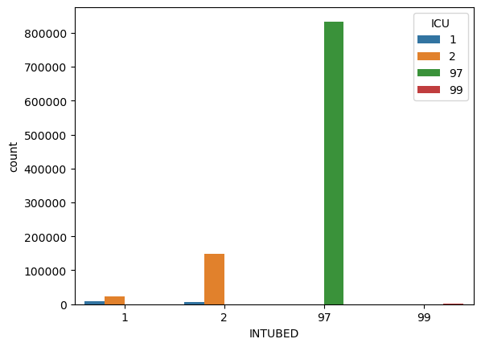

```python
# create a plot of counts for each of the variables in the INTUBED column and color by ICU values
sns.countplot(covid, x="INTUBED", hue="ICU")
```

There does appear to be a correlation between the INTUBED and ICU variables. The value 97 appears to be the same in both columns. This was interesting especially considering the high number of 97s. I decided to search for further relationships to other variables.

I realized that patients who are intubed and in the ICU are both going to be in the hospital. This corresponds with the PATIENT_TYPE column. I decided to see if there was a relationship between ICU, INTUBED, and PATIENT_TYPE.

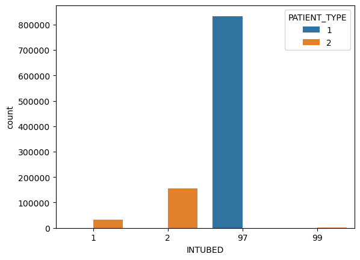

```python
# create a plot of counts for the  INTUBED column and color by PATIENT_TYPE (1-hospitalized, 2-not hospitalized)
sns.countplot(covid, x="INTUBED", hue="PATIENT_TYPE")
```

The countplot shows that all of the patients that are intubed are also in the hospital. The patients that are not in the hospital are categorized as N/A in the INTUBED column. Thus, in the INTUBED column, all of the 97 values can be replaced by 2, stating that these patients are not intubed.

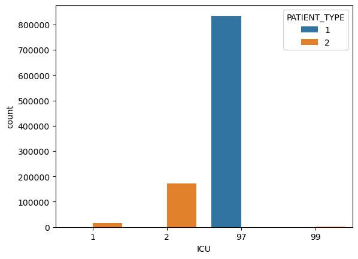

```python
# create a plot of counts for the ICU column and color by PATIENT_TYPE (1-hospitalized, 2-not hospitalized)
sns.countplot(covid, x="ICU", hue="PATIENT_TYPE")
```

The ICU column follows the same pattern as the INTUBED column. All of the 97s in the ICU column represent patients that are not hospitalized. Therefore, these 97s can be categorized as 2s meaning that they are not in the ICU.

```python
covid['ICU'].replace(97, 2, inplace=True)
covid['INTUBED'].replace(97, 2, inplace=True)
```

The 99 values in ICU and INTUBED columns are very few and seem to be actual null values. Those values can be removed from the dataset.

```python
covid.drop(covid[covid["ICU"]==99].index, inplace=True) #Remove 99s in the ICU column
covid.drop(covid[covid["INTUBED"]==99].index, inplace=True) #Remove 99s in the INTUBED column
```

##### Exploring the PREGNANT Column

The PREGNANT column also has too many N/A values to remove. I wanted to take a look at this variable to see if I could identify some of the N/A variables.

I thought that some of the N/A values could be due to the gender of the patient.

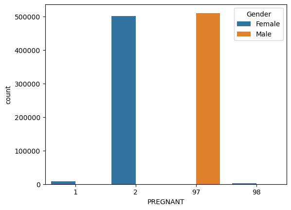

```python
# Create a countplot showing the PREGNANT column and coloring by SEX
sns.countplot(x="PREGNANT", hue="SEX", data=covid)
plt.legend(title='Gender', labels=['Female', 'Male'])
```

The countplot shows that all of the men in the dataset are categorized as 97 in the pregnant column. The data was recorded by stating male pregnancy as impossible and thus an N/A value. The 97s in this column can be replaced by 2s because the males in the data cannot be pregnant.

In the PREGNANT column, the value 98 is infrequent and unpredictable enough to be considered an N/A value and removed.

```python
#Drop the rows where the column PREGNANT is equal to 98
covid.drop(covid[covid["PREGNANT"]==98].index, inplace=True)

# Replace any instance of 97 in the PREGNANT column with 2 to show that male patients are not pregnant
covid['PREGNANT'].replace(97, 2, inplace=True)
```

##### Removing Unnecessary and Unhelpful Columns

One column that will not be helpful in predicting the severity of Covid in a patient is DATE_DIED. If the patient is dead, the severity of Covid no longer matters for them. This column can be removed to remove bias from the model.

```python
covid.drop("DATE_DIED", axis=1, inplace=True)
```

Another couple of unhelpful variables are the medical unit variable and the USMER variable. The categories for these two variables are not explained. The 13 different medical units are not given and neither are the two different types of USMR. Thereful, no helpful information can be drawn from these variables.

```python
covid.drop("MEDICAL_UNIT", axis=1, inplace=True)
covid.drop("USMER", axis=1, inplace=True)
```

The final step in the data cleaning process is to make sure that all of the N/A values have been taken care of

```python
#Print off values counts for each column to make sure there are no longer any N/A values
for column in covid.columns:
    print(covid[column].value_counts())
```

```
SEX
2    510596
1    509070
Name: count, dtype: int64
PATIENT_TYPE
1    830385
2    189281
Name: count, dtype: int64
INTUBED
2    986730
1     32936
Name: count, dtype: int64
PNEUMONIA
2.0    883254
1.0    136412
Name: count, dtype: int64
AGE
30     26435
31     25386
28     24708
29     24574
32     24375
       ...
115        2
119        2
111        1
121        1
113        1
Name: count, Length: 121, dtype: int64
PREGNANT
2    1011838
1       7828
Name: count, dtype: int64
DIABETES
2.0    898137
1.0    121529
Name: count, dtype: int64
COPD
2.0    1005398
1.0      14268
```

[output cut: 31 more lines]

```
1.0     82359
Name: count, dtype: int64
CLASIFFICATION_FINAL
7    488131
3    375920
6    117178
5     25175
1      8397
4      3082
2      1783
Name: count, dtype: int64
ICU
2    1003258
1      16408
Name: count, dtype: int64
```

### Population and Representation for the Model

The goal of the model is to look at a Covid patient's current symptoms, status, and medical history to predict whether a patient is at high risk or not. Thus the population consists of all patients either with Covid or thought to have Covid. In order to make sure that the model correctly identifies high risk patients without bias, the population in the data analyzed must be equally representative of all classes.

##### Gender Class

One class that should be addressed is the sex of the patient.

Sex should be distributed evenly between male and female as this is how gender naturally appears.

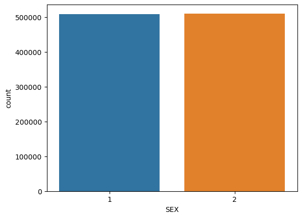

```python
sns.countplot(covid, x="SEX")
```

It appears that sex is evenly distributed between males and females so this class is accurately represented in the population of the data.

##### Age Class

The next class that I wanted to look at is age. Age is typically distributed with a majority of the population being between approximately 20 and 60 years of age. Thus, the data for this population should roughly follow the same distribution.

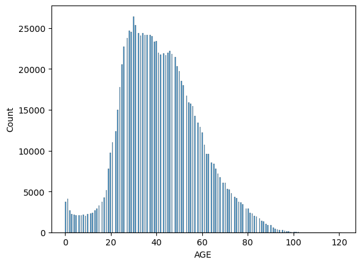

```python
sns.histplot(covid, x="AGE")
```

The distribution of the data closely follows that of the U.S. population. Thus, the age class is accurately represented.

##### Covid Classification Class

The last class to look at in the data is the classification class. There should be a good spread of patients diagnosed with covid of various stages as well as patients without Covid.

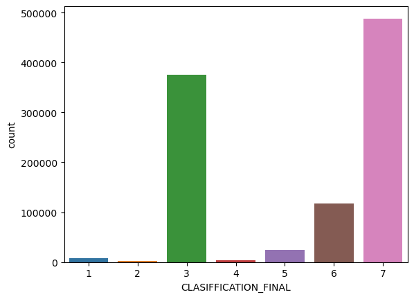

```python
sns.countplot(covid, x="CLASIFFICATION_FINAL")
```

The data contains 7 values for classifying if a patient has covid or not. Values 1-3 show that a patient was diagnosed with Covid and values 4-7 indicate that the test was either inconclusive or not a carrier of covid.

Since there is no specification on what levels 4-7 (patients without Covid) represent, I will combine values 4-7 into one value: 0 to show that the patient does not have Covid.

```python
for value in range(4,8): #for variables with the values of 4-7
    # Replace the value (4-7) with 0
    covid['CLASIFFICATION_FINAL'].replace(value, 0, inplace=True)
```

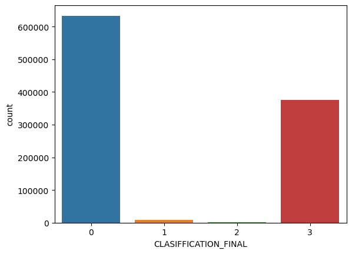

```python
sns.countplot(covid, x="CLASIFFICATION_FINAL")
```

Grouping these values in Covid classification should ensure the model more accurately predicts patients without Covid.

I decided to determine if the values 1-3 should be combined into one category of those who have covid or whether they should be kept and used to describe what degree of Covid that patient has.

I am going to see if I can determine how bad a patient has Covid by seeing if they were hospitalized, intubated, or put in the ICU at different rates between the different categories of classification.

```python
#Create a table that shows the counts of patients that went to the ICU based on which classification group they are in.
ICUcounts= covid.groupby("CLASIFFICATION_FINAL")["ICU"].value_counts().unstack(fill_value=0) #.unstack makes the dataframe print in an easier to read way

#This line creates a column in the dataframe that represents the ratio of patients in the ICU to the total number of patients in each group.
ICUcounts["Ratio of yes / total"] = ICUcounts[1] / (ICUcounts[1]+ICUcounts[2])

ICUcounts
```

| ICU CLASIFFICATION_FINAL | 1 | 2 | Ratio of yes / total |
| --- | --- | --- | --- |
| 0 | 6203 | 627363 | 0.009791 |
| 1 | 250 | 8147 | 0.029773 |
| 2 | 90 | 1693 | 0.050477 |
| 3 | 9865 | 366055 | 0.026242 |

The table above shows no significant difference between the ratio of patients in the ICU and patients not in the ICU for groups 1, 2, and 3. Thus, based on this table, there is no indication of what classification group has the highest level of Covid.

```python
#Create a table that shows the counts of patients that were intubated based on which classification group they are in.
INTUBEDcounts= covid.groupby("CLASIFFICATION_FINAL")["INTUBED"].value_counts().unstack(fill_value=0)

#This line creates a column in the dataframe that represents the ratio of intubated patients to the total number of patients in each group.
INTUBEDcounts["Ratio of yes / total"] = INTUBEDcounts[1] / (INTUBEDcounts[1]+INTUBEDcounts[2])

INTUBEDcounts
```

| INTUBED CLASIFFICATION_FINAL | 1 | 2 | Ratio of yes / total |
| --- | --- | --- | --- |
| 0 | 9655 | 623911 | 0.015239 |
| 1 | 411 | 7986 | 0.048946 |
| 2 | 542 | 1241 | 0.303982 |
| 3 | 22328 | 353592 | 0.059396 |

```python
#Create a table that shows the counts of patients that were in the hospital based on which classification group they are in.
PATIENTTYPEcounts= covid.groupby("CLASIFFICATION_FINAL")["PATIENT_TYPE"].value_counts().unstack(fill_value=0)

#This line creates a column in the dataframe that represents the ratio of hospitalized patients to the total number of patients in each group.
PATIENTTYPEcounts["Ratio of Hospitalized / total "] = PATIENTTYPEcounts[2] / (PATIENTTYPEcounts[1]+PATIENTTYPEcounts[2])

PATIENTTYPEcounts
```

| PATIENT_TYPE CLASIFFICATION_FINAL | 1 | 2 | Ratio of Hospitalized / total |
| --- | --- | --- | --- |
| 0 | 552445 | 81121 | 0.128039 |
| 1 | 6328 | 2069 | 0.246398 |
| 2 | 151 | 1632 | 0.915311 |
| 3 | 271461 | 104459 | 0.277876 |

This table shows that patients in group 2 were more likely to be hospitalized than patients in group 1 and 3. This suggests that patients in group 2 have a higher degree of Covid than those in group 1 and 3.

Since none of the tables were in agreeance over which group is the group with the worst degree of Covid. I will combine groups 1, 2, and 3 into one group of all patients with diagnosed Covid.

The classification column now shows whether a patient has Covid (1) or does not have Covid (0). I will rename this column to more accurately describe the purpose of the column.

```python
for value in range(1,4):
    covid['CLASIFFICATION_FINAL'].replace(value, 1, inplace=True) #replace the values 1-3 with 1

covid.rename(columns={'CLASIFFICATION_FINAL' : 'HAS_COVID'}, inplace=True) #Rename the column

covid.head() #Make sure the changes were correctly made
```

|  | SEX | PATIENT_TYPE | INTUBED | PNEUMONIA | AGE | PREGNANT | DIABETES | COPD | ASTHMA | INMSUPR | HIPERTENSION | OTHER_DISEASE | CARDIOVASCULAR | OBESITY | RENAL_CHRONIC | TOBACCO | HAS_COVID | ICU |
| --- | --- | --- | --- | --- | --- | --- | --- | --- | --- | --- | --- | --- | --- | --- | --- | --- | --- | --- |
| 0 | 1 | 1 | 2 | 1.0 | 65 | 2 | 2.0 | 2.0 | 2.0 | 2.0 | 1.0 | 2.0 | 2.0 | 2.0 | 2.0 | 2.0 | 1 | 2 |
| 1 | 2 | 1 | 2 | 1.0 | 72 | 2 | 2.0 | 2.0 | 2.0 | 2.0 | 1.0 | 2.0 | 2.0 | 1.0 | 1.0 | 2.0 | 0 | 2 |
| 2 | 2 | 2 | 1 | 2.0 | 55 | 2 | 1.0 | 2.0 | 2.0 | 2.0 | 2.0 | 2.0 | 2.0 | 2.0 | 2.0 | 2.0 | 1 | 2 |
| 3 | 1 | 1 | 2 | 2.0 | 53 | 2 | 2.0 | 2.0 | 2.0 | 2.0 | 2.0 | 2.0 | 2.0 | 2.0 | 2.0 | 2.0 | 0 | 2 |
| 4 | 2 | 1 | 2 | 2.0 | 68 | 2 | 1.0 | 2.0 | 2.0 | 2.0 | 1.0 | 2.0 | 2.0 | 2.0 | 2.0 | 2.0 | 1 | 2 |

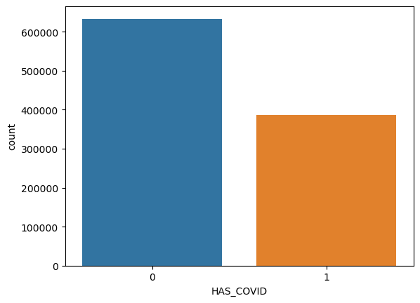

```python
sns.countplot(covid, x="HAS_COVID")
```

After redefining the classification column, the class is distrubuted fairly between those with Covid and those without Covid. It is expected that less people will test positive for Covid than those who test negative. Therefore, the population should be unbiased.

##### Other Classes

The rest of the variables are health complications that might affect the severity of Covid in a patient. These variables should be much less frequently occuring in patients.

To ensure that this is true, the value counts for each other variable can be analyzed to ensure that there are no unexpected classes that might bias the population.

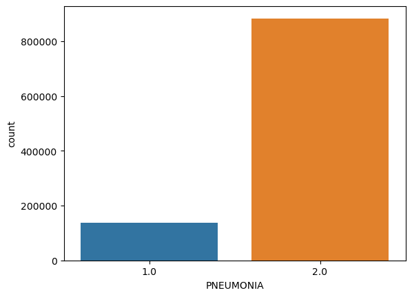

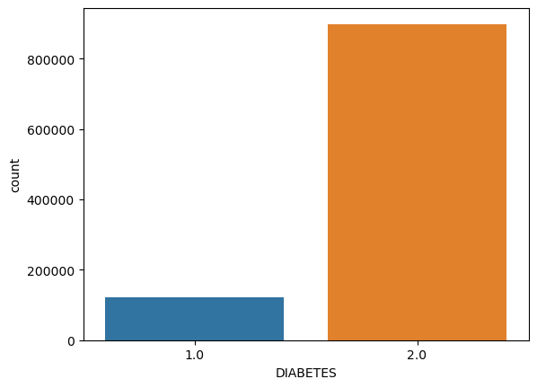

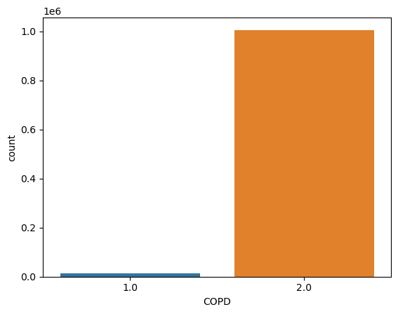

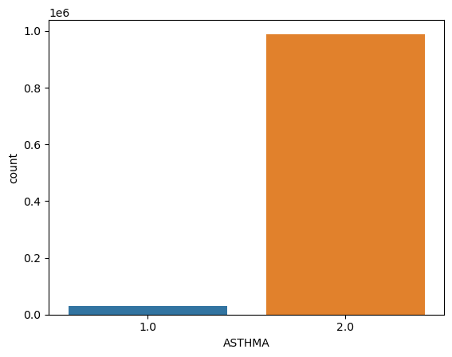

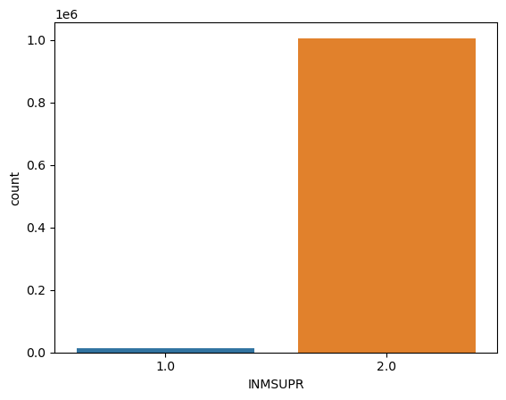

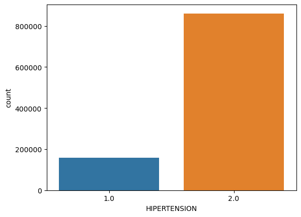

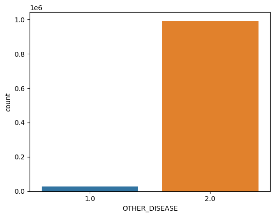

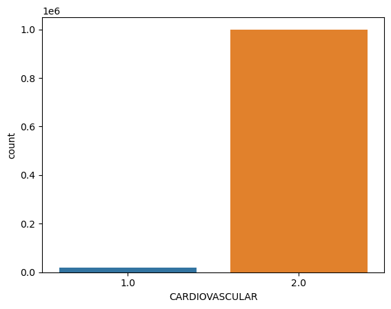

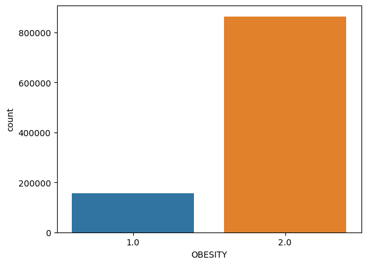

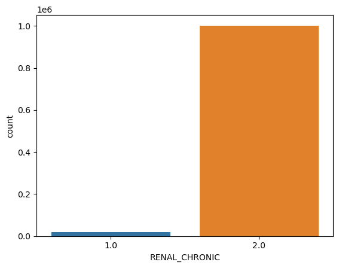

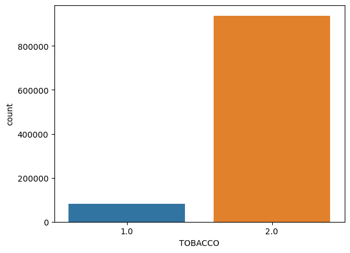

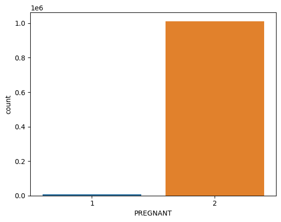

```python
columns_of_interest = ['PNEUMONIA', 'DIABETES', 'COPD', 'ASTHMA', 'INMSUPR', 'HIPERTENSION', 'OTHER_DISEASE', 'CARDIOVASCULAR', 'OBESITY', 'RENAL_CHRONIC', 'TOBACCO', "PREGNANT"]
for column in columns_of_interest: #create a count plot for each of the other classes in the dataset
    sns.countplot(covid, x=column)
    plt.show()
```

The proportion of these variables is reasonable in the context of the data's population. These variables should be good to use in predicting whether a patient is high risk.

### Variable Engineering and Feature Selection

To better and more consistently format the variables, I will change from the current format (1-yes 2-no) to instead be 1-yes, 0-no. This is a more common use of binary variables and will make the modeling easier in the future.

```python
#Check which columns will need to be changed and add them to a list:
col_to_change = ['INTUBED', 'PNEUMONIA', 'DIABETES', 'COPD', 'ASTHMA', 'INMSUPR', 'HIPERTENSION', 'OTHER_DISEASE', 'CARDIOVASCULAR', 'OBESITY', 'RENAL_CHRONIC', 'TOBACCO', "PREGNANT", "ICU"]
covid.head()
```

|  | SEX | PATIENT_TYPE | INTUBED | PNEUMONIA | AGE | PREGNANT | DIABETES | COPD | ASTHMA | INMSUPR | HIPERTENSION | OTHER_DISEASE | CARDIOVASCULAR | OBESITY | RENAL_CHRONIC | TOBACCO | HAS_COVID | ICU |
| --- | --- | --- | --- | --- | --- | --- | --- | --- | --- | --- | --- | --- | --- | --- | --- | --- | --- | --- |
| 0 | 1 | 1 | 2 | 1.0 | 65 | 2 | 2.0 | 2.0 | 2.0 | 2.0 | 1.0 | 2.0 | 2.0 | 2.0 | 2.0 | 2.0 | 1 | 2 |
| 1 | 2 | 1 | 2 | 1.0 | 72 | 2 | 2.0 | 2.0 | 2.0 | 2.0 | 1.0 | 2.0 | 2.0 | 1.0 | 1.0 | 2.0 | 0 | 2 |
| 2 | 2 | 2 | 1 | 2.0 | 55 | 2 | 1.0 | 2.0 | 2.0 | 2.0 | 2.0 | 2.0 | 2.0 | 2.0 | 2.0 | 2.0 | 1 | 2 |
| 3 | 1 | 1 | 2 | 2.0 | 53 | 2 | 2.0 | 2.0 | 2.0 | 2.0 | 2.0 | 2.0 | 2.0 | 2.0 | 2.0 | 2.0 | 0 | 2 |
| 4 | 2 | 1 | 2 | 2.0 | 68 | 2 | 1.0 | 2.0 | 2.0 | 2.0 | 1.0 | 2.0 | 2.0 | 2.0 | 2.0 | 2.0 | 1 | 2 |

```python
# Make sure all of the values in the dataset are integers instead of floats
covid = covid.astype(int)

# Replacing 2 with 0 for each of the relevant columns:
for col in col_to_change:
    covid[col].replace(2, 0, inplace=True)
    covid[col].replace(2.0, 0, inplace=True)

covid
```

|  | SEX | PATIENT_TYPE | INTUBED | PNEUMONIA | AGE | PREGNANT | DIABETES | COPD | ASTHMA | INMSUPR | HIPERTENSION | OTHER_DISEASE | CARDIOVASCULAR | OBESITY | RENAL_CHRONIC | TOBACCO | HAS_COVID | ICU |
| --- | --- | --- | --- | --- | --- | --- | --- | --- | --- | --- | --- | --- | --- | --- | --- | --- | --- | --- |
| 0 | 1 | 1 | 0 | 1 | 65 | 0 | 0 | 0 | 0 | 0 | 1 | 0 | 0 | 0 | 0 | 0 | 1 | 0 |
| 1 | 2 | 1 | 0 | 1 | 72 | 0 | 0 | 0 | 0 | 0 | 1 | 0 | 0 | 1 | 1 | 0 | 0 | 0 |
| 2 | 2 | 2 | 1 | 0 | 55 | 0 | 1 | 0 | 0 | 0 | 0 | 0 | 0 | 0 | 0 | 0 | 1 | 0 |
| 3 | 1 | 1 | 0 | 0 | 53 | 0 | 0 | 0 | 0 | 0 | 0 | 0 | 0 | 0 | 0 | 0 | 0 | 0 |
| 4 | 2 | 1 | 0 | 0 | 68 | 0 | 1 | 0 | 0 | 0 | 1 | 0 | 0 | 0 | 0 | 0 | 1 | 0 |
| ... | ... | ... | ... | ... | ... | ... | ... | ... | ... | ... | ... | ... | ... | ... | ... | ... | ... | ... |
| 1048570 | 2 | 1 | 0 | 0 | 40 | 0 | 0 | 0 | 0 | 0 | 0 | 0 | 0 | 0 | 0 | 0 | 0 | 0 |
| 1048571 | 2 | 2 | 0 | 0 | 51 | 0 | 0 | 0 | 0 | 0 | 1 | 0 | 0 | 0 | 0 | 0 | 0 | 0 |
| 1048572 | 2 | 1 | 0 | 0 | 55 | 0 | 0 | 0 | 0 | 0 | 0 | 0 | 0 | 0 | 0 | 0 | 0 | 0 |
| 1048573 | 2 | 1 | 0 | 0 | 28 | 0 | 0 | 0 | 0 | 0 | 0 | 0 | 0 | 0 | 0 | 0 | 0 | 0 |
| 1048574 | 2 | 1 | 0 | 0 | 52 | 0 | 0 | 0 | 0 | 0 | 0 | 0 | 0 | 0 | 0 | 0 | 0 | 0 |

1019666 rows × 18 columns

The next step that I took was to take all of the columns with values other than 1s and 0s and change them into a different and more cohesive format.

I first redefined the SEX column by breaking it into two columns: FEMALE and MALE with 1 meaning yes and 0 meaning no. This will allow the format of the data to be consistent and will hopefully improve a machine learning model.

```python
# I started with this code but it was taking a very long time to run and it seemed redundant.
# I asked ChatGPT to rewrite it and make it run faster
'''
covid['FEMALE'] = 0
covid['MALE'] = 0
for index, value in enumerate(covid["SEX"]):
    if value == 1:
        covid.at[index, 'FEMALE'] = 1
        covid.at[index, 'MALE'] = 0
    else:
        covid.at[index, 'MALE'] = 1
        covid.at[index, 'FEMALE'] = 0
'''
# Here is the code ChatGPT gave me:

covid['FEMALE'] = 0
covid['MALE'] = 0

# Use values in the 'SEX' column to fill in 1s in the FEMALE and MALE columns.
covid['FEMALE'] = (covid['SEX'] == 1).astype(int)
covid['MALE'] = (covid['SEX'] == 2).astype(int)

#The SEX column can now be removed.
covid.drop("SEX", axis=1, inplace=True)
```

The next column that can be changed to 1/0 binary is the PATIENT_TYPE column. I also decided to change the column name to HOSPITALIZED so that it better reflects the information it holds. 1 means that a patient is hospitalized and 0 means that the patient is not hospitalized.

```python
covid['HOSPITALIZED'] = 0 #Create a new column called HOSPITALIZED and set it equal to 0

# Use the PATIENT_TYPE column to set values in the HOSPITALIZED column
##I based this code on the code that chatGPT gave me in the last code chunk
covid['HOSPITALIZED'] = (covid['PATIENT_TYPE'] == 2).astype(int)

#The PATIENT_TYPE column can now be removed.
covid.drop("PATIENT_TYPE", axis=1, inplace=True)
```

The next step I took in variable engineering was creating columns for age ranges rather than having the one column with with continuous ages in it.

```python
#Creating the different age groups and adding 1s for yes and 0s for no

#Create a column for children ages 0-12 based on the AGES column.
covid["CHILD(0-12)"] = (covid["AGE"]<=12).astype(int)

#Create a column for ages 13-65 based on the AGES column.
covid["AGE(13-65)"] = ((covid['AGE']>12) & (covid['AGE']<=65)).astype(int)

#Create a column for Seniors older than 65 based on the AGES column.
covid["SENIOR(>65)"] = (covid['AGE']>65).astype(int)

#The age column can now be removed
covid.drop("AGE", axis=1, inplace=True)
```

Now that all of the features have been created and chosen for the model, the target column must be created.

The target of the model is to predict what kind of resource an individual might need based on their symptoms. This will vary based on a few different variables. In this dataset, there are now three major different kinds of patients. Those without Covid, those with Covid but not hospitalized, and those with Covid that are hospitalized. Each of these three categories will need different levels of care. Thus the model should be able to predict which of these categories a patient falls into.

A category must be created to categorize these patients. The TARGET column will represent the three groups. 0 will represent patients without Covid, 1 will represent patients with Covid but not needing hospitalization. 2 will represent patients with Covid that do need hospitalization.

```python
covid["TARGET"]=0 #Create a TARGET column and set all values equal to zero
for i in covid.index: #for each index in the covid dataset

    if (covid.loc[i, "HAS_COVID"]==1) & (covid.loc[i, "HOSPITALIZED"]==1): #if the patient has covid and is hospitalized
        covid.loc[i, "TARGET"] = 2 #their TARGET value is set to 2

    elif (covid.loc[i, "HAS_COVID"]==1) & (covid.loc[i, "HOSPITALIZED"]==0): #if the patient has covid and is not hospitalized
        covid.loc[i, "TARGET"] = 1 #their TARGET value is set to 1

#because all of the values in the TARGET column were originally set to 0, any patient without Covid will have a TARGET value of 0
```

```python
covid #Print out the dataframe to make sure the data is correct.
```

|  | INTUBED | PNEUMONIA | PREGNANT | DIABETES | COPD | ASTHMA | INMSUPR | HIPERTENSION | OTHER_DISEASE | CARDIOVASCULAR | ... | TOBACCO | HAS_COVID | ICU | FEMALE | MALE | HOSPITALIZED | CHILD(0-12) | AGE(13-65) | SENIOR(>65) | TARGET |
| --- | --- | --- | --- | --- | --- | --- | --- | --- | --- | --- | --- | --- | --- | --- | --- | --- | --- | --- | --- | --- | --- |
| 0 | 0 | 1 | 0 | 0 | 0 | 0 | 0 | 1 | 0 | 0 | ... | 0 | 1 | 0 | 1 | 0 | 0 | 0 | 1 | 0 | 1 |
| 1 | 0 | 1 | 0 | 0 | 0 | 0 | 0 | 1 | 0 | 0 | ... | 0 | 0 | 0 | 0 | 1 | 0 | 0 | 0 | 1 | 0 |
| 2 | 1 | 0 | 0 | 1 | 0 | 0 | 0 | 0 | 0 | 0 | ... | 0 | 1 | 0 | 0 | 1 | 1 | 0 | 1 | 0 | 2 |
| 3 | 0 | 0 | 0 | 0 | 0 | 0 | 0 | 0 | 0 | 0 | ... | 0 | 0 | 0 | 1 | 0 | 0 | 0 | 1 | 0 | 0 |
| 4 | 0 | 0 | 0 | 1 | 0 | 0 | 0 | 1 | 0 | 0 | ... | 0 | 1 | 0 | 0 | 1 | 0 | 0 | 0 | 1 | 1 |
| ... | ... | ... | ... | ... | ... | ... | ... | ... | ... | ... | ... | ... | ... | ... | ... | ... | ... | ... | ... | ... | ... |
| 1048570 | 0 | 0 | 0 | 0 | 0 | 0 | 0 | 0 | 0 | 0 | ... | 0 | 0 | 0 | 0 | 1 | 0 | 0 | 1 | 0 | 0 |
| 1048571 | 0 | 0 | 0 | 0 | 0 | 0 | 0 | 1 | 0 | 0 | ... | 0 | 0 | 0 | 0 | 1 | 1 | 0 | 1 | 0 | 0 |
| 1048572 | 0 | 0 | 0 | 0 | 0 | 0 | 0 | 0 | 0 | 0 | ... | 0 | 0 | 0 | 0 | 1 | 0 | 0 | 1 | 0 | 0 |
| 1048573 | 0 | 0 | 0 | 0 | 0 | 0 | 0 | 0 | 0 | 0 | ... | 0 | 0 | 0 | 0 | 1 | 0 | 0 | 1 | 0 | 0 |
| 1048574 | 0 | 0 | 0 | 0 | 0 | 0 | 0 | 0 | 0 | 0 | ... | 0 | 0 | 0 | 0 | 1 | 0 | 0 | 1 | 0 | 0 |

1019666 rows × 22 columns

## Modeling

To model the data, I chose to use a random forest model. I chose this model due to the type of data that is presented in this dataset. The model is a classification model that will also be able to help me identify the variables that are the most important to classifying a patient. Being able to look at variable importance was something that I felt was neccessary for this situation as it is important to see what factors might be most concerning in a Covid patient. In the same way, the random forest model will be able to classify patients into one of three groups rather than just classifying between two groups.

#### First Model

For my first random forest model, I chose to throw every variable at the model that I could, just to see which variables were the most important to identifying at risk patients.

```python
#Make a list of all of the variables that I will be using in the model.
inputs = covid[['INTUBED', 'PNEUMONIA', 'PREGNANT', 'DIABETES', 'COPD', 'ASTHMA',
       'INMSUPR', 'HIPERTENSION', 'OTHER_DISEASE', 'CARDIOVASCULAR', 'OBESITY',
       'RENAL_CHRONIC', 'TOBACCO', 'ICU', 'FEMALE', 'MALE', 'CHILD(0-12)', 'AGE(13-65)', 'SENIOR(>65)']]

#Make a variable to store my target column in
target = covid["TARGET"]

#Create a training an testing split in the data
X_train, X_test, y_train, y_test = train_test_split(inputs, target, test_size=0.3, random_state=37, stratify=target)
```

I will first create a copy of the train and test data so I can use the same data throughout my analyses without worrying about accidentally compromising the data source.

```python
X_train_1 = copy.deepcopy(X_train)
X_test_1 = copy.deepcopy(X_test)
y_train_1 = copy.deepcopy(y_train)
y_test_1 = copy.deepcopy(y_test)
```

Next, in order to do a multi-class classification, I will need to convert my target variable into binary format, splitting the single column into three binary columns.

```python
#Convert the target variable to binary format (one-hot encoding)
#The call of np.unique makes sure that the target variable retains all of the classes even after the split
y_train_bin_1 = label_binarize(y_train_1, classes=np.unique(y_train_1))
y_test_bin_1 = label_binarize(y_test_1, classes=np.unique(y_train_1))
```

Next I will initialize the random forest clasifyer and make sure that it uses the OneVsRestClassifier due to the multiclass classification that I am performing. The OneVsRestClassifier will essentially turn the one multiclass problem into three binary classifications.

```python
# Initialize the RandomForestClassifier and set it to a random state of 37 so that it is replicable
model = RandomForestClassifier(random_state=37)

#Ensure the model uses the one-vs-rest strategy
model_ovr = OneVsRestClassifier(model)
```

I will now fit the model and print the model's accuracy score.

```python
model_ovr.fit(X_train_1, y_train_bin_1)
score = model_ovr.score(X_test_1, y_test_bin_1)
print("Accuracy: ", score)
```

```
Accuracy:  0.628787185354691
```

The accuracy of the test is not as high as I would like, however it is more accurate than a 33% chance guess between the three classifications.

I will now print out a confusion matrix to better understand the accuracy score.

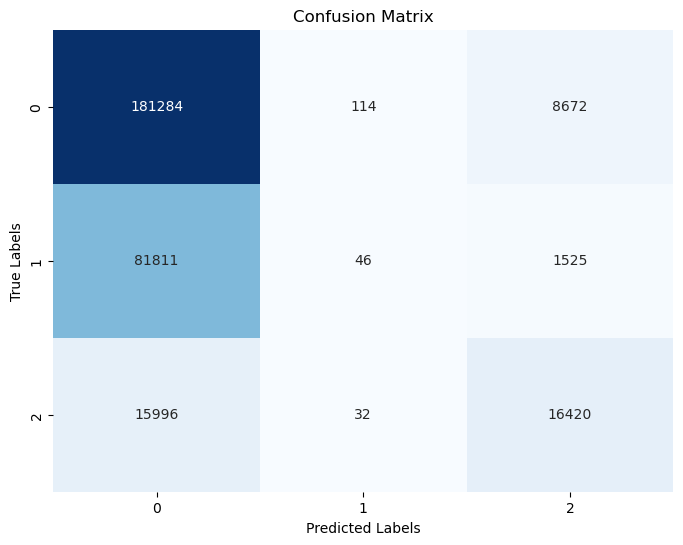

```python
#Predictions
y_pred = model_ovr.predict(X_test_1)

#Convert back from the one-hot encoding labels to the original class labels
y_test_class = np.argmax(y_test_bin_1, axis=1)
y_pred_class = np.argmax(y_pred, axis=1)

#Create confusion matrix
conf_matrix = confusion_matrix(y_test_class, y_pred_class)

#Plot the confusion matrix and using parameters to make the matrix easier to read
#I used chatGPT to help me identify what parameters to use to get the graph how I wanted it to look
plt.figure(figsize=(8, 6))
sns.heatmap(conf_matrix, annot=True, fmt="d", cmap="Blues", cbar=False,
            xticklabels=model_ovr.classes_, yticklabels=model_ovr.classes_)
plt.title("Confusion Matrix")
plt.xlabel("Predicted Labels")
plt.ylabel("True Labels")
plt.show()
```

The confusion matrix shows that the model was very accurate in predicting true negatives. Patients without Covid were easily identified by the model. That being said, there were also higher levels of false negatives in the model. This may be caused by the higer proportion of patients in group 0 in the data.

```python
# Print the classification report
print("Classification Report:\n", classification_report(y_test_bin_1, y_pred))
```

```
Classification Report:
               precision    recall  f1-score   support

           0       0.66      0.93      0.77    190070
           1       0.24      0.00      0.00     83382
           2       0.62      0.51      0.56     32448

   micro avg       0.66      0.63      0.64    305900
   macro avg       0.50      0.48      0.44    305900
weighted avg       0.54      0.63      0.54    305900
 samples avg       0.63      0.63      0.63    305900
```

Next, I computed the ROC scores for each of the classes and plotted them to learn even more about the model.

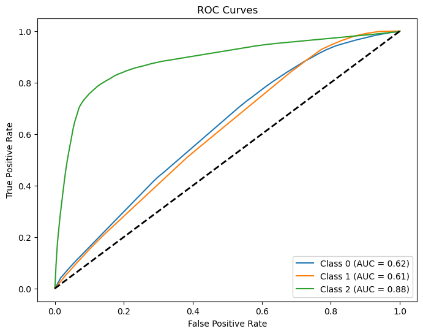

```python
# Predict probabilities for each class on the test set
y_score = model_ovr.predict_proba(X_test_1)

#Create empty dictionaries to store false positive rates, true positive rates, and roc_auc scores for each variable
fpr = dict()
tpr = dict()
roc_auc = dict()

#Compute ROC curve and ROC area for each of the three classes
for i in range(0,3):
    fpr[i], tpr[i], _ = roc_curve(y_test_bin_1[:, i], y_score[:, i]) # the _ stores the unwanted information about thresholds and is not used further in the code
    roc_auc[i] = auc(fpr[i], tpr[i])

#Plot ROC curve for each class
plt.figure(figsize=(8, 6))

for i in range(0,3): # the label section of this code was given to me by chatGPT after I asked how to better label this graph
    plt.plot(fpr[i], tpr[i], label=f'Class {i} (AUC = {roc_auc[i]:.2f})')

plt.plot([0, 1], [0, 1], 'k--', lw=2) #plots a dashed line to give something to compare the ROC curves to
plt.xlabel('False Positive Rate')
plt.ylabel('True Positive Rate')
plt.title('ROC Curves')
plt.legend(loc="lower right")
plt.show()
```

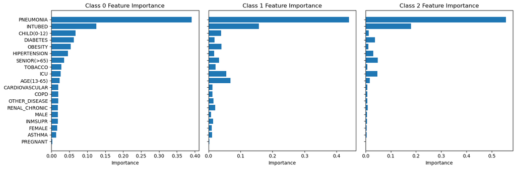

```python
## I originally had code that was printing the importance plots manually in their own windows but I asked chatGTP to rewrite it and combine them into one window
# Plotting feature importances for each class side by side

# Set up subplots
fig, axes = plt.subplots(nrows=1, ncols=3, figsize=(15, 5), sharey=True)

# Loop through each class
for i in range(0,3):
    # Extract feature importances from the base model for the current class
    class_importances = model_ovr.estimators_[i].feature_importances_

    # Creating a DataFrame for easier plotting
    importance_df = pd.DataFrame({'Feature': X_train.columns, 'Importance': class_importances})

    # Sorting the DataFrame by importance
    importance_df = importance_df.sort_values(by='Importance', ascending=True)

    # Plotting the feature importance with flipped x and y axes
    axes[i].barh(importance_df['Feature'], importance_df['Importance'])
    axes[i].set_xlabel('Importance')
    axes[i].set_title(f'Class {i} Feature Importance')

# Adjust layout and show the plot
plt.tight_layout()
plt.show()
```

Looking at the plots of variable importance for each of the classes, it appears that there are many variables that are not as useful in predicting classes. I do not want to manually remove columns from the model but I will implement a hyper parameter that will change the number of features used in the next model. I believe this is the most strategic way to make sure only the most important columns are used.

Altogether, the first model was an improvement to just guessing the severity of a Covid patient. However, the model shows room for improvement. I will attempt to improve the model by adding and tuning hyperparameters.

#### Adding and Tuning Hyperparameters

Hyperparameter 1: Maximum Number of Features (max_features)

I am going to be running a for loop that will try out different number of features and will print the results in a graph. I will then be able to choose the number that maximizes the model score.

```python
#Recopy test and Train data
X_train_2 = copy.deepcopy(X_train)
X_test_2 = copy.deepcopy(X_test)
y_train_bin_2 = copy.deepcopy(y_train_bin_1)
y_test_bin_2 = copy.deepcopy(y_test_bin_1)
```

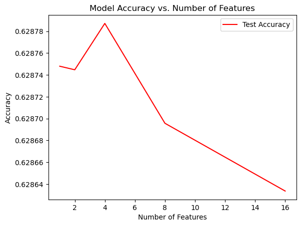

```python
n_features = [1, 2, 4, 8, 16] #Create list of numbers of features to try
test_results = [] #Empty list for testing results

for feature in n_features:
    rf = RandomForestClassifier(random_state=37, max_features=feature, n_jobs=-1)
    model_ovr = OneVsRestClassifier(rf)  # Wrap RandomForestClassifier in OneVsRestClassifier
    model_ovr.fit(X_train_2, y_train_bin_2)

    # Testing accuracy
    test_accuracy = model_ovr.score(X_test_2, y_test_bin_2)
    test_results.append(test_accuracy)

# Plotting the results
plt.plot(n_features, test_results, 'r', label='Test Accuracy')
plt.xlabel('Number of Features')
plt.ylabel('Accuracy')
plt.title('Model Accuracy vs. Number of Features')
plt.legend()
plt.show()
```

Based on this hyperparameter tuning, it appears that accuracy peaks at 4 maximum features. This will get rid of the unneccessary features in the plot.

Hyperparameter 2: Maximum Number of Estimators (n_estimators)

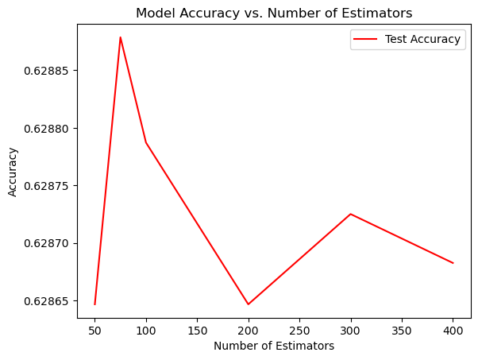

```python
n_estimators = [50, 75, 100, 200, 300, 400]
train_results = []
test_results = []

for est in n_estimators:
    rf = RandomForestClassifier(random_state=37, max_features=4, n_estimators=est, n_jobs=-1)
    model_ovr = OneVsRestClassifier(rf)  # Wrap RandomForestClassifier in OneVsRestClassifier
    model_ovr.fit(X_train_2, y_train_bin_2)

    # Testing accuracy
    test_accuracy = model_ovr.score(X_test_2, y_test_bin_2)
    test_results.append(test_accuracy)

# Plotting the results
plt.plot(n_estimators, test_results, 'r', label='Test Accuracy')
plt.xlabel('Number of Estimators')
plt.ylabel('Accuracy')
plt.title('Model Accuracy vs. Number of Estimators')
plt.legend()
plt.show()
```

Based on this hyperparameter tuning, it appears that accuracy peaks at 75 estimators. Making this change will hopefully increase the overall accuracy of the model.

#### Final Model

For my final forest model, I will add in the tuned hyperparameters to the model. This should change the features used as well as how many trees are used to classify the patients. I am hoping this improves the model.

```python
#Recopy test and Train data
X_train_f = copy.deepcopy(X_train)
X_test_f = copy.deepcopy(X_test)
y_train_bin_f = copy.deepcopy(y_train_bin_1)
y_test_bin_f = copy.deepcopy(y_test_bin_1)
```

I will once again initialize the random forest clasifyer and make sure that it uses the OneVsRestClassifier.

```python
# Initialize the RandomForestClassifier and set it to a random state of 37 so that it is replicable
model = RandomForestClassifier(random_state=37, max_features=4, n_estimators=75)

#Ensure the model uses the one-vs-rest strategy
model_ovr_f = OneVsRestClassifier(model)
```

I will now fit the model and print the model's accuracy score.

```python
model_ovr_f.fit(X_train_f, y_train_bin_f)
score = model_ovr_f.score(X_test_f, y_test_bin_f)
print("Accuracy: ", score)
```

```
Accuracy:  0.6288787185354691
```

I will now print out a confusion matrix to better understand the accuracy score.

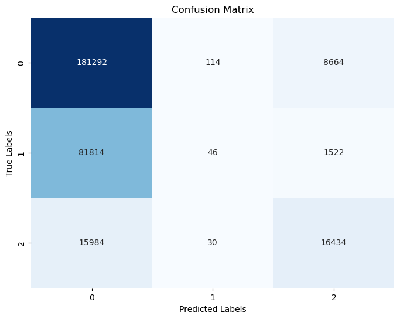

```python
#Predictions
y_pred = model_ovr_f.predict(X_test_f)

#Convert back from the one-hot encoding labels to the original class labels
y_test_class = np.argmax(y_test_bin_f, axis=1)
y_pred_class = np.argmax(y_pred, axis=1)

#Create confusion matrix
conf_matrix = confusion_matrix(y_test_class, y_pred_class)

#Plot the confusion matrix and using parameters to make the matrix easier to read
#I used chatGPT to help me identify what parameters to use to get the graph how I wanted it to look
plt.figure(figsize=(8, 6))
sns.heatmap(conf_matrix, annot=True, fmt="d", cmap="Blues", cbar=False,
            xticklabels=model_ovr_f.classes_, yticklabels=model_ovr_f.classes_)
plt.title("Confusion Matrix")
plt.xlabel("Predicted Labels")
plt.ylabel("True Labels")
plt.show()
```

This matrix as compared to the first matrix had no major change. But, the model correctly identified more class zero and class 2 patients. There were slightly fewer incorrectly labeled patients.

```python
# Print the classification report
print("Classification Report:\n", classification_report(y_test_bin_f, y_pred))
```

```
Classification Report:
               precision    recall  f1-score   support

           0       0.66      0.93      0.77    190070
           1       0.24      0.00      0.00     83382
           2       0.62      0.51      0.56     32448

   micro avg       0.66      0.63      0.64    305900
   macro avg       0.51      0.48      0.44    305900
weighted avg       0.54      0.63      0.54    305900
 samples avg       0.63      0.63      0.63    305900
```

There was not enough of a change in the model to induce a change in the precision and recall of the classes. Therefore, nothing in the explanation of these variables has changed since the previous model.

Next, I computed the ROC scores for each of the classes and plotted them to hopefully learn more about the model.

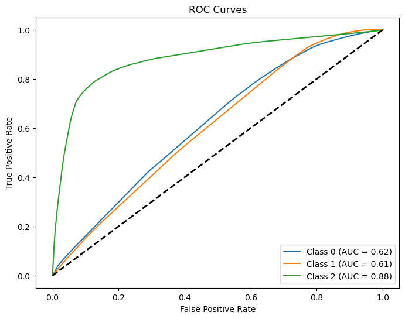

```python
# Predict probabilities for each class on the test set
y_score = model_ovr_f.predict_proba(X_test_f)

#Create empty dictionaries to store false positive rates, true positive rates, and roc_auc scores for each variable
fpr = dict()
tpr = dict()
roc_auc = dict()

#Compute ROC curve and ROC area for each of the three classes
for i in range(0,3):
    fpr[i], tpr[i], _ = roc_curve(y_test_bin_f[:, i], y_score[:, i]) # the _ stores the unwanted information about thresholds and is not used further in the code
    roc_auc[i] = auc(fpr[i], tpr[i])

#Plot ROC curve for each class
plt.figure(figsize=(8, 6))

for i in range(0,3): # the label section of this code was given to me by chatGPT after I asked how to better label this graph
    plt.plot(fpr[i], tpr[i], label=f'Class {i} (AUC = {roc_auc[i]:.2f})')

plt.plot([0, 1], [0, 1], 'k--', lw=2) #plots a dashed line to give something to compare the ROC curves to
plt.xlabel('False Positive Rate')
plt.ylabel('True Positive Rate')
plt.title('ROC Curves')
plt.legend(loc="lower right")
plt.show()
```

There was also no significant change in the AUC scores for this model. Class 2 still has the best discriminitory power.

#### Final Thoughts

The model did not improve as much as I wanted it to. However, I believe that the model is still a good addition to the healthcare system. I believe that, given more data on patients with Covid, the model could start to pick up more patterns for the smaller classes (class 1 and 2), and eventually become more accurate in identifying the differing levels of Covid patients.

The model is more accurate than just guessing how many resources will be needed to keep up with Covid patients. Thus, I believe it is helpful.

Even the ability and resources to help one more patient than before makes this model worthwhile.

Given enough time and data, I beleive this model could be optimized even further to be of more help to the healthcare system.